8. This exercise relates to the **College** data set, which can be found in the file **College.csv.** It contains a number of variables for 777 different universities and colleges in the US. The variables are
   - **Private** : Public/private indicator
   - **Apps** : Number of applications received
   - **Accept** : Number of applicants accepted
   - **Enroll** : Number of new students enrolled
   - **Top10perc** : New students from the top 10 % of high school class
   - **top25perc** : New students from the top 25 % of high school class
   - **F.Undergrad** : Number of full-time undergraduates
   - **P.Undergrad** : Number of part-time undergraduates
   - **Outstate** : Out-of-state tuition
   - **Room.Board** : Room and board costs
   - **Books** : Estimated book costs
   - **Personal** : Estimated personal spending
   - **PhD** : Percent of faculty with Ph.D’s
   - **Terminal** : Percent of faculty with terminal degree
   - **S.F.Ratio** : Student/faculty ratio
   - **perc.alumni** : Percent of alumni who donate
   - **Expend** : Instructional expenditure per student
   - **Grad.Rate** : Graduation rate

   Before reading the data into **R**, it can be viewed in Excel or a text editor.
   1. Use the **read.csv()** function to read the data into **R.** Call the loaded data **college.** Make sure that you have the directoy set to the correct location for the data.

   ````
    ```r
      library(ISLR)
      setwd("~/Analytics/ISLR/Chapter2")
    ```
   ````

   2. Look at the data using the **fix()** function. You should notice that the first column is just the name of each university. We on’t really want **R** to treat this as data. However, it may be handy to have these names for later. Try the following commands:

   ```r
     #rownames(college)=college[,1]
     #fix(college) #This command is not supported in Rstudio
   ```

   You should see that there is now a **row.names** column with the name of each university recorded. This means that **R** has given each row a name corresponding to the appropriate university. **R** will not try to perform calculations on the row names. However, we still need to eliminate the first column in the data where the names are stored. Try

   ````
    ```r
      #college=college[,1]
      #fix(college)
    ```
   ````

   Now you should see that the first data column is **Private.** Note that another column labeled **row.names** now appears before the **Private** column. However, this is not a data column but rather the name that **R** is giving to each row.
   3. 1. Use the **summary()** function to produce a numerical summary of the variables in the data set.

      ```r
      summary(College)
      ```

      ```
      ##  Private        Apps           Accept          Enroll       Top10perc
      ##  No :212   Min.   :   81   Min.   :   72   Min.   :  35   Min.   : 1.00
      ##  Yes:565   1st Qu.:  776   1st Qu.:  604   1st Qu.: 242   1st Qu.:15.00
      ##            Median : 1558   Median : 1110   Median : 434   Median :23.00
      ##            Mean   : 3002   Mean   : 2019   Mean   : 780   Mean   :27.56
      ##            3rd Qu.: 3624   3rd Qu.: 2424   3rd Qu.: 902   3rd Qu.:35.00
      ##            Max.   :48094   Max.   :26330   Max.   :6392   Max.   :96.00
      ##    Top25perc      F.Undergrad     P.Undergrad         Outstate
      ##  Min.   :  9.0   Min.   :  139   Min.   :    1.0   Min.   : 2340
      ##  1st Qu.: 41.0   1st Qu.:  992   1st Qu.:   95.0   1st Qu.: 7320
      ##  Median : 54.0   Median : 1707   Median :  353.0   Median : 9990
      ##  Mean   : 55.8   Mean   : 3700   Mean   :  855.3   Mean   :10441
      ##  3rd Qu.: 69.0   3rd Qu.: 4005   3rd Qu.:  967.0   3rd Qu.:12925
      ##  Max.   :100.0   Max.   :31643   Max.   :21836.0   Max.   :21700
      ##    Room.Board       Books           Personal         PhD
      ##  Min.   :1780   Min.   :  96.0   Min.   : 250   Min.   :  8.00
      ##  1st Qu.:3597   1st Qu.: 470.0   1st Qu.: 850   1st Qu.: 62.00
      ##  Median :4200   Median : 500.0   Median :1200   Median : 75.00
      ##  Mean   :4358   Mean   : 549.4   Mean   :1341   Mean   : 72.66
      ##  3rd Qu.:5050   3rd Qu.: 600.0   3rd Qu.:1700   3rd Qu.: 85.00
      ##  Max.   :8124   Max.   :2340.0   Max.   :6800   Max.   :103.00
      ##     Terminal       S.F.Ratio      perc.alumni        Expend
      ##  Min.   : 24.0   Min.   : 2.50   Min.   : 0.00   Min.   : 3186
      ##  1st Qu.: 71.0   1st Qu.:11.50   1st Qu.:13.00   1st Qu.: 6751
      ##  Median : 82.0   Median :13.60   Median :21.00   Median : 8377
      ##  Mean   : 79.7   Mean   :14.09   Mean   :22.74   Mean   : 9660
      ##  3rd Qu.: 92.0   3rd Qu.:16.50   3rd Qu.:31.00   3rd Qu.:10830
      ##  Max.   :100.0   Max.   :39.80   Max.   :64.00   Max.   :56233
      ##    Grad.Rate
      ##  Min.   : 10.00
      ##  1st Qu.: 53.00
      ##  Median : 65.00
      ##  Mean   : 65.46
      ##  3rd Qu.: 78.00
      ##  Max.   :118.00
      ```

      2. Use the **pairs()** function to produce a scatterplot matrix of the first ten columns or variables of the data. Recall that you can reference the first ten columns of a matrix **A** using **A[,1:10].**

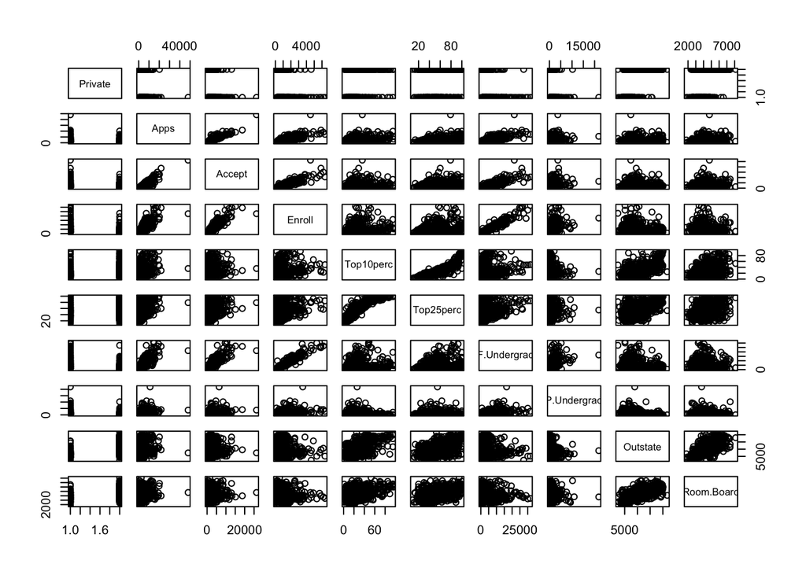

   ```r
   pairs(College[,1:10])
   ```

   iii Use the **plot()** function to produce side-by-side boxplots of **Outstate** vs **Private.**

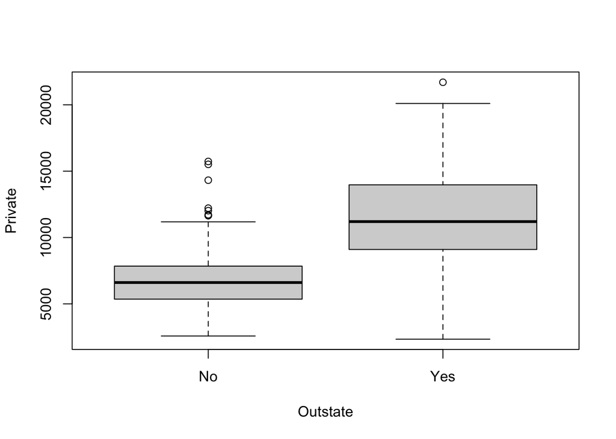

   ```r
   plot(Outstate~Private, data = College, xlab = "Outstate" , ylab = "Private")
   ```

   iv. Create a new qualitative variable, called **Elite,** by *binning* the **Top10perc** variable. We are going to divide universities into two groups based on whether or not the proportion of students coming from the top 10% of their high school classes exceeds 50%.

   ```r
   Elite <- rep(0, nrow(College))
   Elite[College$Top10perc>50] <- 1
   College <- data.frame(College, Elite)
   ```

   ```
    v. Use the **summary()** function to see how many elite universities there are. Now use the **plot()** function to produce side-by-side boxplots of **Outstate** versus **Elite.**
   ```

   ```r
   summary(College)
   ```

   ```
   ##  Private        Apps           Accept          Enroll       Top10perc
   ##  No :212   Min.   :   81   Min.   :   72   Min.   :  35   Min.   : 1.00
   ##  Yes:565   1st Qu.:  776   1st Qu.:  604   1st Qu.: 242   1st Qu.:15.00
   ##            Median : 1558   Median : 1110   Median : 434   Median :23.00
   ##            Mean   : 3002   Mean   : 2019   Mean   : 780   Mean   :27.56
   ##            3rd Qu.: 3624   3rd Qu.: 2424   3rd Qu.: 902   3rd Qu.:35.00
   ##            Max.   :48094   Max.   :26330   Max.   :6392   Max.   :96.00
   ##    Top25perc      F.Undergrad     P.Undergrad         Outstate
   ##  Min.   :  9.0   Min.   :  139   Min.   :    1.0   Min.   : 2340
   ##  1st Qu.: 41.0   1st Qu.:  992   1st Qu.:   95.0   1st Qu.: 7320
   ##  Median : 54.0   Median : 1707   Median :  353.0   Median : 9990
   ##  Mean   : 55.8   Mean   : 3700   Mean   :  855.3   Mean   :10441
   ##  3rd Qu.: 69.0   3rd Qu.: 4005   3rd Qu.:  967.0   3rd Qu.:12925
   ##  Max.   :100.0   Max.   :31643   Max.   :21836.0   Max.   :21700
   ##    Room.Board       Books           Personal         PhD
   ##  Min.   :1780   Min.   :  96.0   Min.   : 250   Min.   :  8.00
   ##  1st Qu.:3597   1st Qu.: 470.0   1st Qu.: 850   1st Qu.: 62.00
   ##  Median :4200   Median : 500.0   Median :1200   Median : 75.00
   ##  Mean   :4358   Mean   : 549.4   Mean   :1341   Mean   : 72.66
   ##  3rd Qu.:5050   3rd Qu.: 600.0   3rd Qu.:1700   3rd Qu.: 85.00
   ##  Max.   :8124   Max.   :2340.0   Max.   :6800   Max.   :103.00
   ##     Terminal       S.F.Ratio      perc.alumni        Expend
   ##  Min.   : 24.0   Min.   : 2.50   Min.   : 0.00   Min.   : 3186
   ##  1st Qu.: 71.0   1st Qu.:11.50   1st Qu.:13.00   1st Qu.: 6751
   ##  Median : 82.0   Median :13.60   Median :21.00   Median : 8377
   ##  Mean   : 79.7   Mean   :14.09   Mean   :22.74   Mean   : 9660
   ##  3rd Qu.: 92.0   3rd Qu.:16.50   3rd Qu.:31.00   3rd Qu.:10830
   ##  Max.   :100.0   Max.   :39.80   Max.   :64.00   Max.   :56233
   ##    Grad.Rate          Elite
   ##  Min.   : 10.00   Min.   :0.0000
   ##  1st Qu.: 53.00   1st Qu.:0.0000
   ##  Median : 65.00   Median :0.0000
   ##  Mean   : 65.46   Mean   :0.1004
   ##  3rd Qu.: 78.00   3rd Qu.:0.0000
   ##  Max.   :118.00   Max.   :1.0000
   ```

   ```r
   #plot(Outstate~Elite, data = College, xlab = "Outstate" , ylab = "Private")
   ```

   ```
    vi. Continue exploring the data. and provide a brief summary of what you discover.
   ```

9. This exercise involves using the **Auto** data set studied in the lab. Make sure that the missing values have been removed from the data.
   1. Which of the predictors are quantitative, and which are qualitative?

   ```r
   data(Auto)
   ```

   Quantitative: mpg,cylinders displacement, horsepower, weight, acceleration, year Qualitative: cylinders,origin,name
   2. What is the *range* of each quantitative predictor? You can answer this using the **range()** function.

   ```r
   range(Auto$mpg)
   ```

   ```
   ## [1]  9.0 46.6
   ```

   ```r
   range(Auto$cylinders)
   ```

   ```
   ## [1] 3 8
   ```

   ```r
   range(Auto$displacement)
   ```

   ```
   ## [1]  68 455
   ```

   ```r
   range(Auto$horsepower)
   ```

   ```
   ## [1]  46 230
   ```

   ```r
   range(Auto$weight)
   ```

   ```
   ## [1] 1613 5140
   ```

   ```r
   range(Auto$acceleration)
   ```

   ```
   ## [1]  8.0 24.8
   ```

   ```r
   range(Auto$year)
   ```

   ```
   ## [1] 70 82
   ```

   3. What is the mean and standard deviation of each quantitative predictor?

   ```r
   mean(Auto$mpg)
   ```

   ```
   ## [1] 23.44592
   ```

   ```r
   mean(Auto$cylinders)
   ```

   ```
   ## [1] 5.471939
   ```

   ```r
   mean(Auto$displacement)
   ```

   ```
   ## [1] 194.412
   ```

   ```r
   mean(Auto$horsepower)
   ```

   ```
   ## [1] 104.4694
   ```

   ```r
   mean(Auto$weight)
   ```

   ```
   ## [1] 2977.584
   ```

   ```r
   mean(Auto$acceleration)
   ```

   ```
   ## [1] 15.54133
   ```

   ```r
   mean(Auto$year)
   ```

   ```
   ## [1] 75.97959
   ```

   ```r
   sd(Auto$mpg)
   ```

   ```
   ## [1] 7.805007
   ```

   ```r
   sd(Auto$cylinders)
   ```

   ```
   ## [1] 1.705783
   ```

   ```r
   sd(Auto$displacement)
   ```

   ```
   ## [1] 104.644
   ```

   ```r
   sd(Auto$horsepower)
   ```

   ```
   ## [1] 38.49116
   ```

   ```r
   sd(Auto$weight)
   ```

   ```
   ## [1] 849.4026
   ```

   ```r
   sd(Auto$acceleration)
   ```

   ```
   ## [1] 2.758864
   ```

   ```r
   sd(Auto$year)
   ```

   ```
   ## [1] 3.683737
   ```

   4. Now remove the 10th through 85th observations. What is the range, mean, and standard deviation of each predictor in the subset of the data that remains?

   ```r
   d <- Auto[-c(10:85), -c(4,9)]
   mean(d$mpg)
   ```

   ```
   ## [1] 24.40443
   ```

   ```r
   mean(d$cylinders)
   ```

   ```
   ## [1] 5.373418
   ```

   ```r
   mean(d$displacement)
   ```

   ```
   ## [1] 187.2405
   ```

   ```r
   mean(d$horsepower)
   ```

   ```
   ## [1] NA
   ```

   ```r
   mean(d$weight)
   ```

   ```
   ## [1] 2935.972
   ```

   ```r
   mean(d$acceleration)
   ```

   ```
   ## [1] 15.7269
   ```

   ```r
   mean(d$year)
   ```

   ```
   ## [1] 77.14557
   ```

   ```r
   sd(d$mpg)
   ```

   ```
   ## [1] 7.867283
   ```

   ```r
   sd(d$cylinders)
   ```

   ```
   ## [1] 1.654179
   ```

   ```r
   sd(d$displacement)
   ```

   ```
   ## [1] 99.67837
   ```

   ```r
   sd(d$horsepower)
   ```

   ```
   ## [1] NA
   ```

   ```r
   sd(d$weight)
   ```

   ```
   ## [1] 811.3002
   ```

   ```r
   sd(d$acceleration)
   ```

   ```
   ## [1] 2.693721
   ```

   ```r
   sd(d$year)
   ```

   ```
   ## [1] 3.106217
   ```

   5. Using the full data set, investigate the predictors graphically, using scatterplots or other tools of your choice.
   6. Suppose that we wish to predict gas mileage (**mpg**) on the basis of the other variables. Do your plots suggest that any of the other variables might be useful in predicting **mpg**? Justify your answer.
10. This exercise involves the **Boston** housing data set.
    1. To begin, load in the **Boston** data set. The **Boston** data set is part of the **MASS** *library* in **R.**

    ```r
    #library(MASS)
    ```

    Now the data set is contained in the object **Boston**

    ```r
    #Boston
    ```

    Read about the data set:

    ```r
    #?Boston
    ```

    How many rows are in this data set? How many columns? What do the rows and columns represent?
    2. Make some pairwise scatterpots of the predictors (columns) in this data set. Describe your findings.
    3. Are any of the predictors associated with per capita crime rate? If so, explain the relationship.
    4. Do any of the suburbs of Boston appear to have particularly high crime rates? Tax rates? Pupil-teacher ratio? Comment on the range of each predictor.
    5. How many of the suburbs in this data set bound the Charles river?
    6. What is the median pupil-teacher ratio among the towns in this data set?
    7. Which suburb of Boston has lowest median value of owner-occupied homes? What are the values of the other predictors for that suburb, and how do those values compare to the overall ranges for those predictors? Comment on your findings.
    8. In this data set, how many of the suburbs average more than seven rooms per dwelling? More than eight rooms per dwelling? Comment on the suburbs that average more than eight rooms per dwelling.